# Practical ML Project

Adam Yao Guang Chen

28 January 2017

## Introduction

Using devices such as Jawbone Up, Nike FuelBand, and Fitbit it is now possible to collect a large amount of data about personal activity relatively inexpensively. These type of devices are part of the quantified self movement - a group of enthusiasts who take measurements about themselves regularly to improve their health, to find patterns in their behavior, or because they are tech geeks. One thing that people regularly do is quantify how much of a particular activity they do, but they rarely quantify how well they do it. In this project, your goal will be to use data from accelerometers on the belt, forearm, arm, and dumbell of 6 participants. They were asked to perform barbell lifts correctly and incorrectly in 5 different ways.

## Initialization

```r
library(RCurl)
library(caret)
library(randomForest)
library(ggplot2)
library(rpart)
library(rpart.plot)
```

## Data Processing

```r
# Download data
URL_Train <-"http://d396qusza40orc.cloudfront.net/predmachlearn/pml-training.csv"
URL_Test <- "https://d396qusza40orc.cloudfront.net/predmachlearn/pml-testing.csv"

File_Train <- "./data/pml-training.csv"
File_Test  <- "./data/pml-testing.csv"

if (!file.exists("./data")) {
  dir.create("./data")
}

download.file(URL_Train, File_Train)
download.file(URL_Test, File_Test)

# Read Data
TrainData = read.csv(File_Train)
TestData = read.csv(File_Test)

dim(TrainData)
```

```
## [1] 19622   160
```

```r
dim(TestData)
```

```
## [1]  20 160
```

```r
#names(TrainData)
```

There are 19622 & 20 observations in training & testing data respectively. The number of variables is 160. The “classe” variable in the training set is the outcome to predict.

## Data cleansing

1. Remove all columns with NA values in test dataset
2. Keep numeric columns & Keep Classes for TrainData
3. Remove columns not much ralevant to the final preditions

```r
# remove columns with NA in TestData
SelectedColumns = colSums(is.na(TestData)) == 0
TrainData = TrainData[, SelectedColumns]
TestData = TestData[, SelectedColumns]

# Keep numeric columns & Keep Classes for TrainData
classe <- TrainData$classe
TrainData <- TrainData[, sapply(TrainData, is.numeric)]
TestData <- TestData[, sapply(TestData, is.numeric)]
TrainData$classe <- classe

# Remove columns not much ralevant to the final preditions
TrainData <- TrainData[, !grepl("^X|timestamp|window", names(TrainData))]
TestData <- TestData[, !grepl("^X|timestamp|window", names(TestData))]

dim(TrainData)
```

```
## [1] 19622    53
```

```r
dim(TestData)
```

```
## [1] 20 53
```

There were 53 variables remained.

## Boosting Model

Fit model with boosting algorithm and 10-fold cross validation to predict “classe” by other variables.

```r
set.seed(1104)
Boosting <- train(classe ~ ., method = "gbm", data = TrainData, verbose = F, trControl = trainControl(method = "cv", number = 10))
Boosting
```

```
## Stochastic Gradient Boosting
##
## 19622 samples
##    52 predictor
##     5 classes: 'A', 'B', 'C', 'D', 'E'
##
## No pre-processing
## Resampling: Cross-Validated (10 fold)
## Summary of sample sizes: 17658, 17659, 17661, 17660, 17659, 17661, ...
## Resampling results across tuning parameters:
##
##   interaction.depth  n.trees  Accuracy   Kappa
##   1                   50      0.7508913  0.6841149
##   1                  100      0.8222926  0.7751024
##   1                  150      0.8540928  0.8153621
##   2                   50      0.8553674  0.8167886
##   2                  100      0.9072475  0.8826251
##   2                  150      0.9333927  0.9157149
##   3                   50      0.8972079  0.8698564
##   3                  100      0.9445540  0.9298504
##   3                  150      0.9638683  0.9542902
##
## Tuning parameter 'shrinkage' was held constant at a value of 0.1
##
## Tuning parameter 'n.minobsinnode' was held constant at a value of 10
## Accuracy was used to select the optimal model using  the largest value.
## The final values used for the model were n.trees = 150,
##  interaction.depth = 3, shrinkage = 0.1 and n.minobsinnode = 10.
```

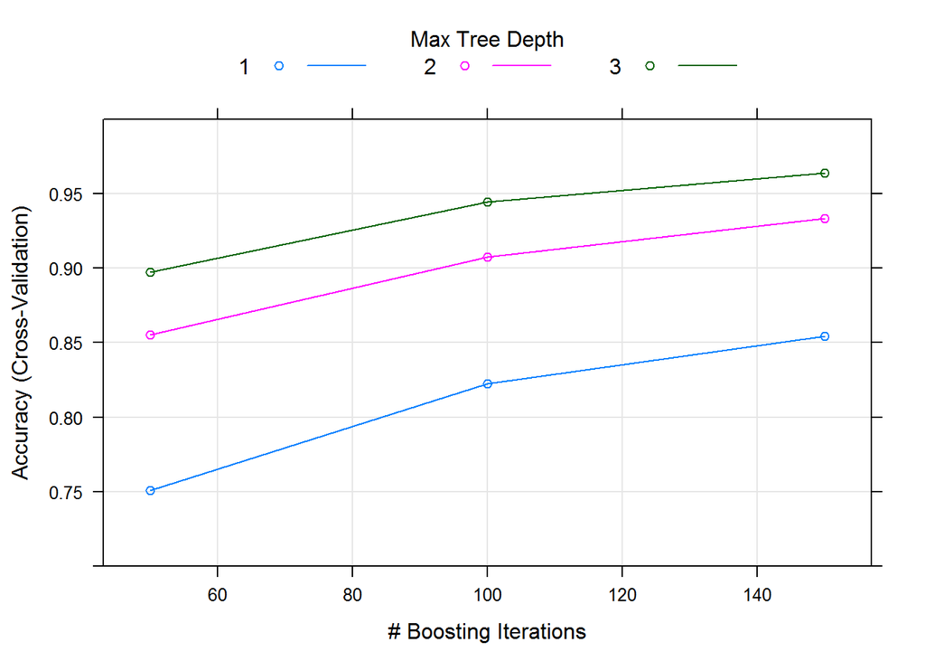

```r
plot(Boosting, ylim = c(0.7, 1))
```

## Random Forests model

Fit model with random forests algorithm and 10-fold cross validation to predict “classe” by other variables.

```r
set.seed(1104)
RandomForests <- train(classe ~ ., method = "rf", data = TrainData, importance = T, trControl = trainControl(method = "cv", number = 10))

#Plot accuracy of this model on the scale of [0.95, 1].
RandomForests
```

```
## Random Forest
##
## 19622 samples
##    52 predictor
##     5 classes: 'A', 'B', 'C', 'D', 'E'
##
## No pre-processing
## Resampling: Cross-Validated (10 fold)
## Summary of sample sizes: 17658, 17659, 17661, 17660, 17659, 17661, ...
## Resampling results across tuning parameters:
##
##   mtry  Accuracy   Kappa
##    2    0.9956683  0.9945207
##   27    0.9954645  0.9942628
##   52    0.9901642  0.9875574
##
## Accuracy was used to select the optimal model using  the largest value.
## The final value used for the model was mtry = 2.
```

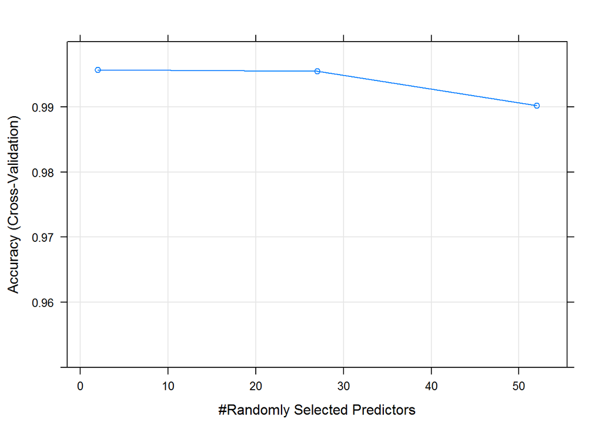

```r
plot(RandomForests, ylim = c(0.95, 1))
```

```r
#The Random Forests algorithm generated an excellent model with accuracy of 99.567% and the estimated out-of-sample error is 0.433%.

RandomForests$finalModel
```

```
##
## Call:
##  randomForest(x = x, y = y, mtry = param$mtry, importance = ..1)
##                Type of random forest: classification
##                      Number of trees: 500
## No. of variables tried at each split: 2
##
##         OOB estimate of  error rate: 0.44%
## Confusion matrix:
##      A    B    C    D    E  class.error
## A 5577    3    0    0    0 0.0005376344
## B   11 3781    5    0    0 0.0042138530
## C    0   17 3404    1    0 0.0052600818
## D    0    0   42 3172    2 0.0136815920
## E    0    0    0    5 3602 0.0013861935
```

```r
# Random Foresters predictions
(prediction <- as.character(predict(RandomForests, TestData)))
```

```
##  [1] "B" "A" "B" "A" "A" "E" "D" "B" "A" "A" "B" "C" "B" "A" "E" "E" "A"
## [18] "B" "B" "B"
```

## Predictions with Random Forests

The random forests algorithm generated a more accurate model with accuracy close to 1. So we’ll choose Random Forests model for prediction.

The final line is predit results of test data.